### Coder School Demo Project

# Leaner Result Predictor

Author: Nguyen Phu Quy

Date 24/04/2022

1. Problem Statement
2. Some Initial Thoughts
3. Dataset & Transforming data
4. Exploratory Data Analysis
5. Methodology & Result
6. Discussion
7. Conclusion

## Problem Statement

CoderSchool is the top coding school in Vietnam. Through high-quality technical training and close partnerships with tech top companies, CoderSchool is one of the best investments learners ever make.

The company automates most of its operations of day-to-day teaching including student progress tracking, submission grading, class attendance, and course personalization. And that is an excellent data foundation for building a data analysis system to improve learners' performance and results.

Therefore, **the research question of this project is what are strong predictors of learner's success throughout courses**.

To answer that, I try to look up some open datasets to demonstrate my methodology and more detail on the dataset below.

## Some Initial Thoughts

Since I have a great passion and experience with learning, especially MOOC, I have learned and completed more than 30 courses in the last several years.

- [Data Analysis with Python - IBM](https://www.coursera.org/account/accomplishments/verify/QBB6X2GHLARN)
- [Python for Data Science, AI & Development](https://www.coursera.org/account/accomplishments/verify/WWTE6QD26Z4W)
- [Data Visualization with Python](https://www.coursera.org/account/accomplishments/verify/NC67R6UZ887C)
- [Google IT Automation with Python](https://www.coursera.org/account/accomplishments/professional-cert/8FXM58263KPH)
- [Databases and SQL for Data Science with Python](https://www.coursera.org/account/accomplishments/verify/MFRK8XB6W8JJ)

Therefore, from my perspective on learning, I think the learner's engagement throughout the course is one of the most critical factors in their achievement. Besides that, another variable is the mastery level of a learner on the topic; if the subject is too complex, they could be overwhelmed and didn't get a good result.

# Dataset & Tranforming data

The dataset is collected from the Assessment and Learning in Knowledge Spaces (ALEKS), which has a sample of 265 students. The program recognizes students' mastery of learned topics after demonstrating their competency of learned objectives on a knowledge assessment and records when students initiate a knowledge assessment. From this score, we can calculate the average percentage improvement of a student after taking these topics. And we call it Retention, a continuous variable.

The software also logged the time a student logs in and out of the system, so we can compute the continuous variable Engage Time from this number.

Finally, there is the number of topics that a student practiced, as well as the number of topics they mastered. We can have another continuous variable, the Ratio of Topics Mastered to Topics Practiced.

The data also includes the gender and ethnicity of those students.

```python
# import libraries
%matplotlib inline
import pandas as pd
import numpy as np
import matplotlib.pyplot as plt
plt.style.use('seaborn-white')
```

```python
!wget -q https://raw.githubusercontent.com/quynguyen2303/learner_success_predictors/main/data/students_scores.csv
```

```python
# load students' score from assessment

url_scores = 'students_scores.csv'
raw_scores = pd.read_csv(url_scores)
print(raw_scores.shape)
raw_scores.head()
```

```
(265, 89)
```

|  | Student | Gender | KC1 | KC2 | Learned topics 1 | KC2.1 | KC3 | Learned topics 2 | KC3.1 | KC4 | ... | Learned topics 26 | KC27.1 | KC28 | Learned topics 27 | KC 28 | KC 29 | Learned topics 28 | KC29 | KC30 | Learned topics 29 |
| --- | --- | --- | --- | --- | --- | --- | --- | --- | --- | --- | --- | --- | --- | --- | --- | --- | --- | --- | --- | --- | --- |
| 0 | 1 | 2 | 100 | 107 | 11 | 107 | 120 | 16 | 120 | 133 | ... | NaN | NaN | NaN | NaN | NaN | NaN | NaN | NaN | NaN | NaN |
| 1 | 2 | 1 | 31 | 40 | 20 | 40 | 50 | 20 | 50 | 57 | ... | NaN | NaN | NaN | NaN | NaN | NaN | NaN | NaN | NaN | NaN |
| 2 | 3 | 2 | 12 | 25 | 20 | 25 | 33 | 20 | 33 | 47 | ... | NaN | NaN | NaN | NaN | NaN | NaN | NaN | NaN | NaN | NaN |
| 3 | 4 | 2 | 29 | 40 | 13 | 40 | 51 | 14 | 51 | 62 | ... | NaN | NaN | NaN | NaN | NaN | NaN | NaN | NaN | NaN | NaN |
| 4 | 5 | 1 | 83 | 90 | 10 | 90 | 99 | 12 | 99 | 108 | ... | NaN | NaN | NaN | NaN | NaN | NaN | NaN | NaN | NaN | NaN |

5 rows × 89 columns

The raw data of students' scores has 265 rows for each students. And have 89 column as below:

- Student: id of a student
- Gendar: 1 is female, 2 is male
- KC1: is the number of mastered topics on an assessment before "Learned topics 1"
- KC2: is the number of mastered topics on an assessment after "Learned topics 1"
- Learned topics 1: a total number of topics that a student learned before an assessment

The system is that a student takes an initial assessment to define mastered topics, then the student practices other topics until amount of time or topics, then the program suggests to do another assessment. The result of a assessment is the amount of mastered topics after learning some topics. We use that to calculate Retention rate of a student through the progress of learning.

For example, student 1 mastered 100 topics and learned more 11 topics, after that the student 1 mastered 107 topics. So, the Retention after learned 11 topics is: (107 - 100)/11 ~ 64%

And we will average this Retention for a student.

We will need to break those columns into each learned topics to calculate the average Retention.

```python
# stores a list of df that break down from raw data
list_of_topics = list()
minus_columns = 2 # first 2 columns are not related to topics
# loop through the 89 columns of raw data and slice it by learned topics
for i in range(2,raw_scores.shape[1]-minus_columns,3):
  students = raw_scores.iloc[:,0:1]
  topic_df = students.join(raw_scores.iloc[:, i:i+3])
  # stores separated topics in to the list
  list_of_topics.append(topic_df)
```

```python
# calculate the Retention rate for each learned topics
for i in range(len(list_of_topics)):
  list_of_topics[i]['retention_' + str(i+1)] = list_of_topics[i].iloc[:,2].subtract(list_of_topics[i].iloc[:,1]).divide(list_of_topics[i].iloc[:,3])
```

```python
# check a topic after calculated average
list_of_topics[2]
```

[output not shown]

265 rows × 5 columns

```python
# merge all the Retention to one master table
# NaN means a student didn't learned any topics at this step
student_scores = raw_scores.iloc[:,0:1] # get the Student column for merge key
for i in range(len(list_of_topics)):
  student_scores = pd.merge(student_scores, list_of_topics[i].iloc[:,0::4], on='Student', how='left')

student_scores.tail()
```

|  | Student | retention_1 | retention_2 | retention_3 | retention_4 | retention_5 | retention_6 | retention_7 | retention_8 | retention_9 | ... | retention_20 | retention_21 | retention_22 | retention_23 | retention_24 | retention_25 | retention_26 | retention_27 | retention_28 | retention_29 |
| --- | --- | --- | --- | --- | --- | --- | --- | --- | --- | --- | --- | --- | --- | --- | --- | --- | --- | --- | --- | --- | --- |
| 260 | 261 | 0.615385 | 0.857143 | 0.562500 | 0.250000 | 0.357143 | 0.583333 | 0.937500 | 0.785714 | 0.750000 | ... | NaN | NaN | NaN | NaN | NaN | NaN | NaN | NaN | NaN | NaN |
| 261 | 262 | 0.705882 | 0.769231 | 0.785714 | 0.714286 | 0.769231 | 0.833333 | 0.700000 | 0.846154 | 0.615385 | ... | NaN | NaN | NaN | NaN | NaN | NaN | NaN | NaN | NaN | NaN |
| 262 | 263 | 1.000000 | 0.800000 | 0.583333 | 0.500000 | 0.666667 | 0.200000 | 0.923077 | 0.666667 | 0.454545 | ... | 0.833333 | NaN | NaN | NaN | NaN | NaN | NaN | NaN | NaN | NaN |
| 263 | 264 | 0.692308 | 0.538462 | 0.538462 | 0.437500 | 0.285714 | 0.076923 | 0.666667 | 0.500000 | 0.611111 | ... | 0.384615 | 0.210526 | NaN | NaN | NaN | NaN | NaN | NaN | NaN | NaN |
| 264 | 265 | 0.529412 | 0.466667 | 0.466667 | 0.500000 | 0.695652 | 0.750000 | 0.500000 | 0.444444 | 0.785714 | ... | NaN | NaN | NaN | NaN | NaN | NaN | NaN | NaN | NaN | NaN |

5 rows × 30 columns

Looking for abnormal values

```python
# check for inf value due to divide by 0
student_scores.isin([np.inf, -np.inf]).sum()
```

```
Student         0
retention_1     0
retention_2     0
retention_3     1
retention_4     0
retention_5     2
retention_6     1
retention_7     2
retention_8     0
retention_9     0
retention_10    1
retention_11    0
retention_12    2
retention_13    0
retention_14    0
retention_15    0
retention_16    0
retention_17    0
retention_18    0
retention_19    0
retention_20    0
retention_21    0
retention_22    0
retention_23    0
retention_24    0
retention_25    0
retention_26    0
retention_27    0
retention_28    0
retention_29    0
dtype: int64
```

Since there are around 9 inf values after the average calculation due to the numerator is negative or the denominator is 0. And it is not significant to the total sample, so we will replace it to NaN and exlcude it when calculat total average.

```python
# group by Student and replace inf value to NaN to exclude when calculate Retention average
student_scores = student_scores.groupby('Student').mean()
student_scores = student_scores.replace([np.inf, -np.inf], np.nan)
student_scores.describe()
```

|  | retention_1 | retention_2 | retention_3 | retention_4 | retention_5 | retention_6 | retention_7 | retention_8 | retention_9 | retention_10 | ... | retention_20 | retention_21 | retention_22 | retention_23 | retention_24 | retention_25 | retention_26 | retention_27 | retention_28 | retention_29 |
| --- | --- | --- | --- | --- | --- | --- | --- | --- | --- | --- | --- | --- | --- | --- | --- | --- | --- | --- | --- | --- | --- |
| count | 265.000000 | 265.000000 | 262.000000 | 265.000000 | 263.000000 | 264.000000 | 262.000000 | 257.000000 | 251.000000 | 245.000000 | ... | 64.000000 | 48.000000 | 36.000000 | 28.000000 | 19.000000 | 15.000000 | 11.000000 | 9.000000 | 5.000000 | 5.000000 |
| mean | 0.634468 | 0.596099 | 0.612939 | 0.600654 | 0.583786 | 0.590619 | 0.573000 | 0.546294 | 0.581088 | 0.575134 | ... | 0.474880 | 0.506199 | 0.428323 | 0.527781 | 0.596691 | 0.427271 | 0.401485 | 0.301053 | 0.717698 | 0.744242 |
| std | 0.355262 | 0.218149 | 0.242752 | 0.275566 | 0.254725 | 0.246796 | 0.275314 | 0.670003 | 0.278931 | 0.303508 | ... | 0.458533 | 0.277563 | 0.320472 | 0.272266 | 0.235743 | 0.269216 | 0.195757 | 0.291052 | 0.096767 | 0.165334 |
| min | -0.642857 | -0.142857 | -0.333333 | -0.666667 | -0.153846 | -0.333333 | -0.500000 | -9.000000 | -0.500000 | -0.800000 | ... | -2.500000 | -0.400000 | -0.333333 | 0.000000 | 0.062500 | -0.142857 | 0.000000 | -0.300000 | 0.600000 | 0.600000 |
| 25% | 0.454545 | 0.450000 | 0.439236 | 0.416667 | 0.405882 | 0.416667 | 0.400000 | 0.400000 | 0.400000 | 0.384615 | ... | 0.356061 | 0.370536 | 0.250000 | 0.326923 | 0.466063 | 0.285714 | 0.346154 | 0.214286 | 0.625000 | 0.636364 |
| 50% | 0.625000 | 0.615385 | 0.654762 | 0.600000 | 0.600000 | 0.615385 | 0.600000 | 0.571429 | 0.600000 | 0.615385 | ... | 0.541958 | 0.535714 | 0.436508 | 0.483333 | 0.600000 | 0.428571 | 0.400000 | 0.266667 | 0.777778 | 0.666667 |
| 75% | 0.800000 | 0.769231 | 0.800000 | 0.800000 | 0.777778 | 0.769231 | 0.775641 | 0.777778 | 0.800000 | 0.785714 | ... | 0.714286 | 0.723214 | 0.675000 | 0.659091 | 0.792857 | 0.645833 | 0.464286 | 0.437500 | 0.785714 | 0.818182 |
| max | 4.000000 | 1.090909 | 1.500000 | 1.571429 | 1.150000 | 1.142857 | 1.083333 | 2.538462 | 1.090909 | 1.400000 | ... | 1.000000 | 0.928571 | 0.849398 | 1.100000 | 1.000000 | 0.818182 | 0.800000 | 0.733333 | 0.800000 | 1.000000 |

8 rows × 29 columns

```python
# Calculate the average Retention for each student through the semester
student_scores = student_scores.mean(axis='columns').reset_index()
student_scores.columns = ['Student', 'Retention']
student_scores.head()
```

|  | Student | Retention |
| --- | --- | --- |
| 0 | 1 | 0.723121 |
| 1 | 2 | 0.532413 |
| 2 | 3 | 0.577049 |
| 3 | 4 | 0.537828 |
| 4 | 5 | 0.730178 |

```python
student_scores.describe()
```

|  | Student | Retention |
| --- | --- | --- |
| count | 265.000000 | 265.000000 |
| mean | 133.000000 | 0.589373 |
| std | 76.643112 | 0.131913 |
| min | 1.000000 | 0.123244 |
| 25% | 67.000000 | 0.513453 |
| 50% | 133.000000 | 0.596799 |
| 75% | 199.000000 | 0.683737 |
| max | 265.000000 | 1.029059 |

Load another dataset that includes Engagment Time (ET) by hours, a continous variable. And Total Topics Mastered (ttm), Total Topics Practiced (ttp). From ttm and ttp, we can calculate the Ratio of Topics Mastered to Topics Practiced by ttm / ttp, this variable might have more meaningful with final score (SFPG, range 0-100).

```python
!wget -q https://raw.githubusercontent.com/quynguyen2303/learner_success_predictors/main/data/students_et_final.csv
```

```python
# load engage time and ttm, ttp data
url_et = 'students_et_final.csv'
raw_final = pd.read_csv(url_et)
print(raw_final.shape)
raw_final.head()
```

```
(265, 5)
```

|  | Student | ET | ttm | ttp | SFPG |
| --- | --- | --- | --- | --- | --- |
| 0 | 1 | 107.183333 | 202 | 257 | 91 |
| 1 | 2 | 116.583333 | 243 | 348 | 78 |
| 2 | 3 | 175.266667 | 301 | 462 | 95 |
| 3 | 4 | 156.600000 | 294 | 470 | 90 |
| 4 | 5 | 142.850000 | 226 | 365 | 73 |

```python
# Change columns to meaningful names
raw_final.columns = ['Student', 'EngageTime', 'TTM', 'TTP','FinalScore']
# Calculate the ratio between mastered topics and practiced topics
raw_final['MasteredRatio'] = raw_final['TTM'].divide(raw_final['TTP'])
students_final = raw_final.loc[:, ['Student', 'EngageTime', 'MasteredRatio','FinalScore']]
students_final.head()
```

|  | Student | EngageTime | MasteredRatio | FinalScore |
| --- | --- | --- | --- | --- |
| 0 | 1 | 107.183333 | 0.785992 | 91 |
| 1 | 2 | 116.583333 | 0.698276 | 78 |
| 2 | 3 | 175.266667 | 0.651515 | 95 |
| 3 | 4 | 156.600000 | 0.625532 | 90 |
| 4 | 5 | 142.850000 | 0.619178 | 73 |

```python
# merge students score with engage time, mastered ration and final score
# to have final df
students_cleaned = student_scores.merge(students_final)
students_cleaned.head()
```

|  | Student | Retention | EngageTime | MasteredRatio | FinalScore |
| --- | --- | --- | --- | --- | --- |
| 0 | 1 | 0.723121 | 107.183333 | 0.785992 | 91 |
| 1 | 2 | 0.532413 | 116.583333 | 0.698276 | 78 |
| 2 | 3 | 0.577049 | 175.266667 | 0.651515 | 95 |
| 3 | 4 | 0.537828 | 156.600000 | 0.625532 | 90 |
| 4 | 5 | 0.730178 | 142.850000 | 0.619178 | 73 |

# Exploratory Data Analysis

We explore the statistics of the data to understand it.

```python
students_cleaned.info()
```

```
<class 'pandas.core.frame.DataFrame'>
Int64Index: 265 entries, 0 to 264
Data columns (total 5 columns):
 #   Column         Non-Null Count  Dtype
---  ------         --------------  -----
 0   Student        265 non-null    int64
 1   Retention      265 non-null    float64
 2   EngageTime     265 non-null    float64
 3   MasteredRatio  265 non-null    float64
 4   FinalScore     265 non-null    int64
dtypes: float64(3), int64(2)
memory usage: 12.4 KB
```

```python
students_cleaned.describe()
```

|  | Student | Retention | EngageTime | MasteredRatio | FinalScore |
| --- | --- | --- | --- | --- | --- |
| count | 265.000000 | 265.000000 | 265.000000 | 265.000000 | 265.000000 |
| mean | 133.000000 | 0.589373 | 155.865660 | 0.686876 | 79.384906 |
| std | 76.643112 | 0.131913 | 52.670671 | 0.083564 | 12.821729 |
| min | 1.000000 | 0.123244 | 49.166667 | 0.437186 | 41.000000 |
| 25% | 67.000000 | 0.513453 | 121.350000 | 0.632000 | 70.000000 |
| 50% | 133.000000 | 0.596799 | 145.166667 | 0.687831 | 79.000000 |
| 75% | 199.000000 | 0.683737 | 179.700000 | 0.747863 | 89.000000 |
| max | 265.000000 | 1.029059 | 470.950000 | 0.874074 | 100.000000 |

The **students' ratio of mastered to practiced** topics had the second highest mean score of 0.69 with a standard deviation of 0.08 and ranged from 0.44 to 0.87 in ratio scores.

The mean for **these final score** was 79.38 with a standard deviation of 12.82 and a range from 41 to 100.

```python
# Normalize the FinalScore column for better visualization
students_cleaned['FinalNorm'] = students_cleaned['FinalScore']/100
```

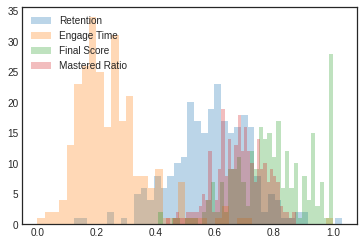

```python
x1 = students_cleaned['Retention']
x2 = students_cleaned['EngageTime']
x2_norm = (x2-x2.min())/(x2.max()-x2.min())
x3 = students_cleaned['FinalNorm']
x4 = students_cleaned['MasteredRatio']

kwargs = dict(histtype='stepfilled', alpha=0.3, bins=40)

plt.hist(x1, **kwargs, label='Retention')
plt.hist(x2_norm, **kwargs, label='Engage Time')
plt.hist(x3, **kwargs, label='Final Score')
plt.hist(x4, **kwargs, label='Mastered Ratio')
plt.legend();
```

The Final Score histogram is more likely a left-skew, and other Retention and Mastered Ratio are more likely normalized.

# Methodology & Result

We want to answer the question:

**Are Engage Time, Retention, Mastered Ratio of learner identified as strong predictors for students' result?**

We using Standard correlation coefficient (Pearson) between Predictors vs Final Score to see the povisitve or negative relationship.

```python
students_cleaned.corr(method='pearson')
```

|  | Student | Retention | EngageTime | MasteredRatio | FinalScore | FinalNorm |
| --- | --- | --- | --- | --- | --- | --- |
| Student | 1.000000 | 0.051185 | 0.034863 | 0.074575 | 0.014354 | 0.014354 |
| Retention | 0.051185 | 1.000000 | -0.121384 | 0.361921 | -0.027423 | -0.027423 |
| EngageTime | 0.034863 | -0.121384 | 1.000000 | -0.149096 | 0.427567 | 0.427567 |
| MasteredRatio | 0.074575 | 0.361921 | -0.149096 | 1.000000 | 0.198224 | 0.198224 |
| FinalScore | 0.014354 | -0.027423 | 0.427567 | 0.198224 | 1.000000 | 1.000000 |
| FinalNorm | 0.014354 | -0.027423 | 0.427567 | 0.198224 | 1.000000 | 1.000000 |

Students' engagement time was the strongest and statistically significant predictor of students' final progress grade scores followed by the mastered to practiced topics. A moderately strong positive relationship existed between engagement time and students' final progress grades (r = .43), and the ratio of mastered to practiced topics depicted a slightly medium positive association with final progress grade scores (r = .20). No statistically significant correlation existed between students’ retention scores and final progress grades.

# Discussion

This analysis is just a demo of what we can achieve with the data collected from learners' behavior. Just from these descriptive and correlation analyses, one can suggest that focusing on increasing the engagement time and helping learners practice to master more topics might help their final result.

But there can be another approach, such as clustering learners into different categories as they progress and then, based on the characteristics of each cluster, defining different approaches to help them.

# Final Conclusion

First of all, thank you for your time in reading this project.

This demo project that I researched and completed on the weekend shows what I might contribute to CoderSchool as a Data Analyst in the Academics team. And how much effort and interest I am in the job.

I hope I can have a chance to understand more about the Data Analyst job on the Academics team.

Quy